# Introduction to Parallel Computing with R

Adam M. Wilson

November 5, 2014

# Introduction to Parallel Computing with R

This script is available:

- [SpatialAnalysisTutorials repository (https://github.com/adammwilson/SpatialAnalysisTutorials)](https://github.com/adammwilson/SpatialAnalysisTutorials)
- HTML format (with images/plots) at http://goo.gl/V4ETTi
- Plain text (.R) with commented text at http://goo.gl/0LxUS6.

```r
library(foreach)
library(doParallel)
library(knitr)
library(raster)
library(rasterVis)
library(arm)
library(coda)
library(fields)
library(dplyr)
library(ggplot2)
library(ggmcmc)
```

If you don't have the packages above, install them in the package manager or by running `install.packages("doParallel")`.

# Introduction

## Serial Computing

Most (legacy) software is written for serial computation:

- Problem broken into discrete set of instructions
- Instructions executed sequentially on a single processor

[figure not shown]

Figure from [here](https://computing.llnl.gov/tutorials/parallel_comp/)

## Parallel computation

Parallel computing is the simultaneous use of multiple compute resources:

- Problem divided into discrete parts that can be solved concurrently
- Instructions from each part execute simultaneously on different processors
- An overall control/coordination mechanism is employed

[figure not shown]

Figure from [here](https://computing.llnl.gov/tutorials/parallel_comp/)

## Flynn's taxonomy

A classification of computer architectures ([Flynn, 1972](http://dx.doi.org/10.1109/TC.1972.5009071))

- *Single Instruction, Single Data (SISD)*
  - No parallelization
- *Single Instruction, Multiple Data (SIMD)*
  - Run the same code/analysis on different datasets
  - Examples:
    - different species in species distribution model
    - same species under different climates
    - different MCMC chains from a Bayesian Model
- *Multiple Instruction, Single Data (MISD)*
  - Run different code/analyses on the same data
  - Examples:
    - One species, multiple models
- *Multiple Instruction, Multiple Data streams (MIMD)*
  - Run different code/analyses on different data
  - Examples:
    - Different species & different models

[figure not shown]

Figure from [here](http://en.wikipedia.org/wiki/Flynn%27s_taxonomy)

## Our focus: *Single Instruction, Multiple Data (SIMD)*

1. Parallel functions within an R script
   - starts on single processor
   - runs looped elements on multiple 'slave' processors
   - returns results of all iterations to the original instance
   - foreach, multicore, plyr, raster
2. Alternative: run many separate instances of R in parallel with `Rscript`
   - need another operation to combine the results
   - preferable for long, complex jobs
   - NOT planning to discuss in this session

### R Packages

There are many R packages for parallelization, check out the CRAN Task View on [High-Performance and Parallel Computing](http://cran.r-project.org/web/views/HighPerformanceComputing.html) for an overview. For example:

- [Rmpi](http://cran.r-project.org/web/packages/Rmpi/index.html): Built on MPI (Message Passing Interface), a de facto standard in parallel computing.
- [snow](http://cran.r-project.org/web/packages/snow/index.html): Simple Network of Workstations can use several standards (PVM, MPI, NWS)
- [parallel](https://stat.ethz.ch/R-manual/R-devel/library/parallel/doc/parallel.pdf) Built in R package (since v2.14.0).

## Foreach Package

In this session we'll focus on the foreach package, which has numerous advantages including:

- intuitive `for()` loop-like syntax
- flexibility of choosing a parallel 'backend' for laptops through to supercomputers (using multicore, parallel, snow, Rmpi, etc.)
- nice options for combining output from parallelized jobs

### Documentation for foreach:

- [foreach manual](http://cran.r-project.org/web/packages/foreach/foreach.pdf)
- [foreach vignette](http://cran.r-project.org/web/packages/foreach/vignettes/foreach.pdf)
- [Nested Loops](http://cran.r-project.org/web/packages/foreach/vignettes/nested.pdf)

### Foreach *backends*

- [doParallel](http://cran.r-project.org/web/packages/doParallel/index.html) best for use on multicore machines (uses `fork` on linux/mac and `snow` on windows).
- [doMPI](http://cran.r-project.org/web/packages/doMPI/vignettes/doMPI.pdf): Interface to MPI (Message-Passing Interface)
- [doSNOW](http://cran.r-project.org/web/packages/doSNOW/doSNOW.pdf): Simple Network of Workstations

# Simple examples

## *Sequential* `for()` loop

```r
x=vector()
for(i in 1:3) x[i]=i^2
x
```

```r
## [1] 1 4 9
```

## *Sequential* `foreach()` loop

```r
x <- foreach(i=1:3) %do% i^2
x
```

```r
## [[1]]
## [1] 1
##
## [[2]]
## [1] 4
##
## [[3]]
## [1] 9
```

Note that `x` is a list with one element for each iterator variable (`i`). You can also specify a function to use to combine the outputs with `.combine`. Let's concatenate the results into a vector with `c`.

## *Sequential* `foreach()` loop with `.combine`

```r
x <- foreach(i=1:3,.combine='c') %do% i^2
x
```

```r
## [1] 1 4 9
```

## *Sequential* `foreach()` loop with `.combine`

```r
x <- foreach(i=1:3,.combine='rbind') %do% i^2
x
```

```r
##          [,1]
## result.1    1
## result.2    4
## result.3    9
```

So far we've only used `%do%` which only uses a single processor.

## *Parallel* `foreach()` loop

Before running `foreach()` in parallel, you have to register a *parallel backend* with one of the `do` functions such as `doParallel()`. On most multicore systems, the easiest backend is typically `doParallel()`. On linux and mac, it uses `fork` system call and on Windows machines it uses `snow` backend. The nice thing is it chooses automatically for the system.

```r
# register specified number of workers
registerDoParallel(3)
# or, reserve all all available cores
#registerDoParallel()
# check how many cores (workers) are registered
getDoParWorkers()
```

```r
## [1] 3
```

> *NOTE* It's a good idea to use n-1 cores for processing (so you can still use your computer to do other things while the analysis is running)

```r
## run the loop
x <- foreach(i=1:3, .combine='c') %dopar% i^2
x
```

```r
## [1] 1 4 9
```

## A slightly more complicated example

In this section we will:

1. Generate data with known parameters
2. Fit multiple chains of a bayesian regression to recover those parameters
3. Compare processing times for sequential vs. parallel execution

Make some data

```r
n <- 100000              # number of data points
x1 <- rnorm (n)          # make up x1 covariate
x2 <- rbinom (n, 1, .5)  #make up x2 covariate
b0 <- 1.8                # set intercept (beta0)
b1 <- 1.5                # set beta1
b2 <- 2                  # set beta2
y <- rbinom (n, 1, invlogit(b0+b1*x1+b2*x2))  # simulate data with noise
data=cbind.data.frame(y=y,x1=x1,x2=x2)
```

Let's look at the data:

```r
kable(head(data),row.names = F,digits = 2)
```

[output not shown]

Now we will specify the number of chains and fit separate bayesian GLMs using bayesglm in the [ARM](http://cran.r-project.org/web/packages/arm/index.html) package.

```r
nchains=3

ptime <- system.time({
  result <- foreach(i=1:nchains,.combine = rbind.data.frame,.packages=c("arm")) %dopar% {
  M1=bayesglm (y ~ x1 + x2, data=data,family=binomial(link="logit"),n.iter=1e8)
  ## return parameter estimates
  cbind.data.frame(chain=i,t(coefficients(M1)))
    }
  })
ptime
```

```r
##    user  system elapsed
##  16.431   3.123  10.400
```

```r
kable(result,digits = 2)
```

| chain | (Intercept) | x1 | x2 |
| --- | --- | --- | --- |
| 1 | 1.8 | 1.48 | 1.99 |
| 2 | 1.8 | 1.48 | 1.99 |
| 3 | 1.8 | 1.48 | 1.99 |

So we were able to perform 3 independent chains in 10.4 seconds. Let's see how long it would have taken in sequence.

```r
stime <- system.time({
  result <- foreach(i=1:nchains,.combine = rbind.data.frame,.packages=c("arm")) %do% {
  M1=bayesglm (y ~ x1 + x2, data=data,family=binomial(link="logit"),n.iter=1e8)
  ## return mean estimates
  cbind.data.frame(chain=i,t(coefficients(M1)))
    }
  })
stime
```

```r
##    user  system elapsed
##   8.312   1.318  10.557
```

## Things to consider

### Organizing results with `.combine`

Typical functions are `c` to make a vector of results, `cbind` or `cbind.data.frame` to make a table where columns correspond to different jobs, and `rbind` or `rbind.data.frame` to make a table where rows correspond to different jobs. But you can use any function that will combine output.

For example, let's extract all posteriors from the model above as `mcmc` objects (from the `coda` library) and then use the `.combine` to put them in an `mcmc.list` ready for further analysis.

> The `.combine` function alone makes `foreach` a really useful function compared to standard R looping functions such as `lapply` or `by`. You can write any `.combine` function you want to assemble the results.

```r
nchains=3
registerDoParallel(3)

  chains <- foreach(i=1:nchains,.combine = 'mcmc.list',.packages = c("arm","coda"),.multicombine=TRUE) %dopar% {
  M1=bayesglm(y ~ x1 + x2, data=data,family=binomial(link="logit"),n.iter=1000)
  ## extract posteriors and convert to mcmc object
  mcmc(sim(M1,500)@coef)
    }
```

That makes is relatively easy to parallelize across chains and combine the results.

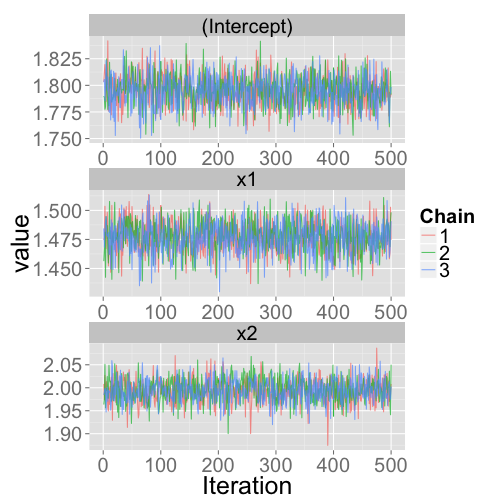

```r
ggs_traceplot(ggs(chains))
```

### Writing data to disk

For long-running processes, you may want to consider writing results to disk *as-you-go* rather than waiting until the end in case of a problem (power failure, single job failure, etc.).

```r
## assign target directory
td=tempdir()

  result <- foreach(i=1:nchains,.combine = rbind.data.frame,.packages=c("arm")) %dopar% {
  M1=bayesglm (y ~ x1 + x2, data=data,family=binomial(link="logit"),n.iter=1000)
  ## return mean estimates
  results=cbind.data.frame(chain=i,t(coefficients(M1)))
  ## write results to disk
  file=paste0(td,"/results_",i,".csv")
  write.csv(results,file=file)
  return(NULL)
    }
```

That will save the result of each subprocess to disk (be careful about duplicated file names!):

```r
list.files(td,pattern="results")
```

```r
## [1] "results_1.csv" "results_2.csv" "results_3.csv"
```

### Other useful `foreach` parameters

- `.inorder` (true/false) results combined in the same order that they were submitted?
- `.errorhandling` (stop/remove/pass)
- `.packages` packages to made available to sub-processes
- `.export` variables to export to sub-processes

# Spatial example

In this section we will:

1. Generate some *spatial* data
2. Tile the region to facilitate processing the data in parallel.
3. Perform a moving window mean for the full area
4. Compare processing times for sequential vs. parallel execution

## Generate Spatial Data

A function to generate `raster` object with spatial autocorrelation.

```r
simrast=function(nx=60,ny=60,theta=10,seed=1234){
      ## create a random raster with some spatial structure
      ## Theta is the scale of an exponential decay function.
      ## This controls degree of autocorrelation,
      ## values close to 1 are close to random while values near nx/4 have high autocorrelation
     r=raster(nrows=ny, ncols=nx,vals=1,xmn=-nx/2, xmx=nx/2, ymn=-ny/2, ymx=ny/2)
      names(r)="z"
      # Simulate a Gaussian random field with an exponential covariance function
      set.seed(seed)  #set a seed so everyone's maps are the same
      grid=list(x=seq(xmin(r),xmax(r)-1,by=res(r)[1]),y=seq(ymin(r),ymax(r)-1,res(r)[2]))
      obj<-Exp.image.cov(grid=grid, theta=theta, setup=TRUE)
      look<- sim.rf( obj)
      values(r)=t(look)*10
      return(r)
      }
```

Generate a raster using `simrast`.

```r
r=simrast(nx=3000,ny=1000,theta = 100)
r
```

```r
## class       : RasterLayer
## dimensions  : 1000, 3000, 3e+06  (nrow, ncol, ncell)
## resolution  : 1, 1  (x, y)
## extent      : -1500, 1500, -500, 500  (xmin, xmax, ymin, ymax)
## coord. ref. : NA
## data source : in memory
## names       : z
## values      : -47.03411, 40.15442  (min, max)
```

Plot the raster showing the grid.

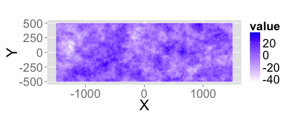

```r
gplot(r)+
  geom_raster(aes(fill = value))+
  scale_fill_gradient(low = 'white', high = 'blue')+
  coord_equal()+ylab("Y")+xlab("X")
```

## "Tile" the region

To parallelize spatial data, you often need to *tile* the data and process each tile separately. Here is a function that will take a bounding box, tile size and generate a tiling system. If given an `overlap` term, it will also add buffers to the tiles to reduce/eliminate edge effects, though this depends on what algorithm/model you are using.

```r
tilebuilder=function(raster,size=10,overlap=NULL){
  ## get raster extents
  xmin=xmin(raster)
  xmax=xmax(raster)
  ymin=ymin(raster)
  ymax=ymax(raster)
  xmins=c(seq(xmin,xmax-size,by=size))
  ymins=c(seq(ymin,ymax-size,by=size))
  exts=expand.grid(xmin=xmins,ymin=ymins)
  exts$ymax=exts$ymin+size
  exts$xmax=exts$xmin+size
  if(!is.null(overlap)){
  #if overlapped tiles are requested, create new columns with buffered extents
    exts$yminb=exts$ymin
    exts$xminb=exts$xmin
    exts$ymaxb=exts$ymax
    exts$xmaxb=exts$xmax

    t1=(exts$ymin-overlap)>=ymin
    exts$yminb[t1]=exts$ymin[t1]-overlap
    t2=exts$xmin-overlap>=xmin
    exts$xminb[t2]=exts$xmin[t2]-overlap
    t3=exts$ymax+overlap<=ymax
    exts$ymaxb[t3]=exts$ymax[t3]+overlap
    t4=exts$xmax+overlap<=xmax
    exts$xmaxb[t4]=exts$xmax[t4]+overlap
  }
  exts$tile=1:nrow(exts)
  return(exts)
}
```

Generate a tiling system for that raster. Here will use only three tiles (feel free to play with this).

```r
jobs=tilebuilder(r,size=1000,overlap=80)
kable(jobs,row.names = F,digits = 2)
```

| xmin | ymin | ymax | xmax | yminb | xminb | ymaxb | xmaxb | tile |
| --- | --- | --- | --- | --- | --- | --- | --- | --- |
| -1500 | -500 | 500 | -500 | -500 | -1500 | 500 | -420 | 1 |
| -500 | -500 | 500 | 500 | -500 | -580 | 500 | 580 | 2 |
| 500 | -500 | 500 | 1500 | -500 | 420 | 500 | 1500 | 3 |

Plot the raster showing the grid.

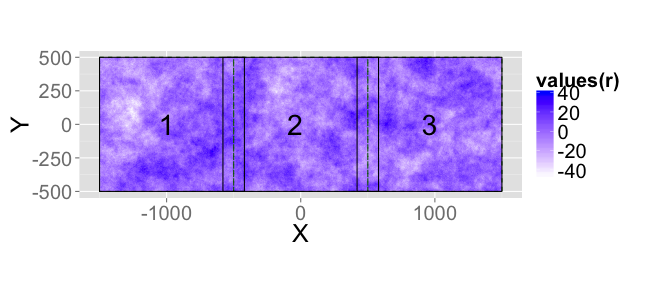

```r
ggplot(jobs)+
  geom_raster(aes(x=coordinates(r)[,1],y=coordinates(r)[,2],fill = values(r)))+
  scale_fill_gradient(low = 'white', high = 'blue')+
  geom_rect(mapping=aes(xmin=xmin,xmax=xmax,ymin=ymin,ymax=ymax),
            fill="transparent",lty="dashed",col="darkgreen")+
  geom_rect(aes(xmin=xminb,xmax=xmaxb,ymin=yminb,ymax=ymaxb),
            fill="transparent",col="black")+
  geom_text(aes(x=(xminb+xmax)/2,y=(yminb+ymax)/2,label=tile),size=10)+
  coord_equal()+ylab("Y")+xlab("X")
```

## Run a simple spatial analysis: `focal` moving window

```r
stime2=system.time({
  r_focal1=focal(r,w=matrix(1,101,101),mean,pad=T)
  })
stime2
```

```r
##    user  system elapsed
##  34.588   0.629  36.851
```

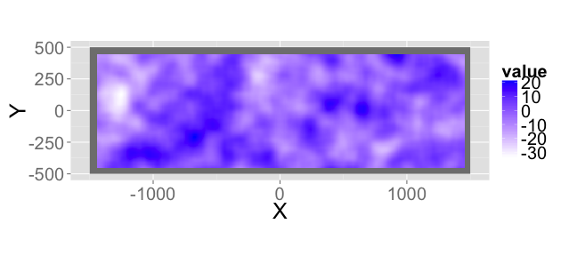

```r
## plot it
gplot(r_focal1)+
  geom_raster(aes(fill = value))+
  scale_fill_gradient(low = 'white', high = 'blue')+
  coord_equal()+ylab("Y")+xlab("X")
```

That works great (and pretty fast) for this little example, but as the data (or the size of the window) get larger, it can become prohibitive.

## Repeat the analysis, but parallelize using the tile system.

First write a function that breaks up the original raster, computes the focal mean, then puts it back together. You could also put this directly in the `foreach()` loop.

```r
focal_par=function(i,raster,jobs,w=matrix(1,101,101)){
  ## identify which row in jobs to process
  t_ext=jobs[i,]
  ## crop original raster to (buffered) tile
  r2=crop(raster,extent(t_ext$xminb,t_ext$xmaxb,t_ext$yminb,t_ext$ymaxb))
  ## run moving window mean over tile
  rf=focal(r2,w=w,mean,pad=T)
  ## crop to tile
  rf2=crop(rf,extent(t_ext$xmin,t_ext$xmax,t_ext$ymin,t_ext$ymax))
  ## return the object - could also write the file to disk and aggregate later outside of foreach()
  return(rf2)
}
```

Run the parallelized version.

```r
registerDoParallel(3)

ptime2=system.time({
  r_focal=foreach(i=1:nrow(jobs),.combine=merge,.packages=c("raster")) %dopar% focal_par(i,r,jobs)
  })
```

Are the outputs the same?

```r
identical(r_focal,r_focal1)
```

```r
## [1] TRUE
```

> R's Raster package can automatically parallelize some functions, check out [`clusterR`](http://www.inside-r.org/packages/cran/raster/docs/endCluster)

# High Performance Computers (HPC)

*aka* *supercomputers*, for example, check out the [Yale HPC](https://hpc.research.yale.edu/hpc_user_wiki/index.php/Yale_HPC_Wiki)

Working on a cluster can be quite different from a laptop/workstation. The most important difference is the existence of *scheduler* that manages large numbers of individual tasks.

## QSUB and R

You typically don't run the script *interactively*, so you need to edit your script to 'behave' like a normal #! (linux command line) script. This is easy with [getopt](http://cran.r-project.org/web/packages/getopt/index.html) package.

```r
cat(paste("

          library(getopt)
          ## get options
          opta <- getopt(matrix(c(
          'date', 'd', 1, 'character'
          ), ncol=4, byrow=TRUE))
          ## extract value
          date=as.Date(opta$date)

          ## Now your script using date as an input

          print(date+1)
          q(\"no\")
          "
          ),file=paste("script.R",sep=""))
```

Then you can run this script from the command line like this:

```r
Rscript script.R --date 2013-11-05
```

Or even from within R like this:

```r
system("Rscript script.R --date '2013-11-05'",intern=T)
```

```r
## [1] "[1] \"2013-11-06\""
```

### Driving cluster from R

> CAVEAT: The following were developed for NASA's Pleiades and not tested on Yale's HPC.

Possible to drive the cluster from within R via QSUB. First, define the jobs and write that file to disk:

```r
script="path_to_script.R"
dates=seq(as.Date("2000-01-01"),as.Date("2000-12-31"),by=60)
pjobs=data.frame(jobs=paste(script,"--date",dates))

write.table(pjobs,
  file="process.txt",
  row.names=F,col.names=F,quote=F)
```

This table has one row per task:

```r
pjobs
```

```r
##                                 jobs
## 1 path_to_script.R --date 2000-01-01
## 2 path_to_script.R --date 2000-03-01
## 3 path_to_script.R --date 2000-04-30
## 4 path_to_script.R --date 2000-06-29
## 5 path_to_script.R --date 2000-08-28
## 6 path_to_script.R --date 2000-10-27
## 7 path_to_script.R --date 2000-12-26
```

Now identify other parameters for QSUB.

```r
### Set up submission script
queue="devel"
nodes=120
walltime=24
```

### Write the QSUB script

```r
### write qsub script to disk from R

cat(paste("
#PBS -S /bin/bash
#PBS -l select=",nodes,":ncpus=8:mpiprocs=8
#PBS -l walltime=",walltime,":00:00
#PBS -q ",queue,"

CORES=",nodes*8,"

IDIR=/path/to/working/dir
WORKLIST=$IDIR/process.txt
EXE=Rscript
LOGSTDOUT=$IDIR/log/stdout
LOGSTDERR=$IDIR/log/stderr

### use mpiexec to parallelize across lines in process.txt
mpiexec -np $CORES pxargs -a $WORKLIST -p $EXE 1> $LOGSTDOUT 2> $LOGSTDERR
",sep=""),file=paste("qsub_script.txt",sep=""))
```

Now we have a list of jobs and a qsub script that points at those jobs with the necessary PBS settings.

```r
## run it!
system("qsub qsub_script.txt")
```

# Summary

> Each task should involve computationally-intensive work. If the tasks are very small, it can take *longer* to run in parallel.

## Choose your method

1. Run from master process (e.g. `foreach`)
   - easier to implement and collect results
   - fragile (one failure can kill it and lose results)
   - clumsy for *big* jobs
2. Run as separate R processes via pxargs
   - see [`getopt`](http://cran.r-project.org/web/packages/getopt/index.html) library
   - safer for big jobs: each job completely independent
   - easy to re-run incomplete submissions
   - compatible with qsub / cluster computing
   - forces you to have a clean processing script

## Further Reading

- [CRAN Task View: High-Performance and Parallel Computing with R](http://cran.r-project.org/web/views/HighPerformanceComputing.html)
- Simple Parallel Statistical Computing in R
- [Parallel Computing with the R Language in a Supercomputing Environment](http://download.springer.com/static/pdf/832/chp%253A10.1007%252F978-3-642-13872-0_64.pdf?auth66=1415215123_43bf0cbf5ae8f5143b7ee309ff5e3556&ext=.pdf)

Styled with knitrBootstrap